# Day 6 lab: intro probability

# Inverse cdf method for continuous random variables

*Premise for Inverse CDF method: When you want random samples from a distribution.*

Here we use examples from distributions that are easy to sample from so we can compare our results with existing functions. In reality this method would be used for uncommon distributions.

## Preparation

First, let’s recall/introduce how we can make our own functions in in R.

Toy example:

```r
add_two_numbers <- function(number1, number2){
  return(number1 + number2)
}

add_two_numbers(number1 = 2, number2 = 9)
```

```
[1] 11
```

```r
# We can call function without argument names but it is not good practice e.g.
add_two_numbers(2, 9)
```

```
[1] 11
```

Before we start generating random numbers, let’s set the seed to make our experiments reproducible.

To understand why we set a seed run the chunk below and compare the output. Then run it again and compare between runs.

```r
rnorm(1)
```

```
[1] 2.274749
```

```r
rnorm(1)
```

```
[1] 0.9803857
```

In order to make our analysis reproducible we need to set the seed, allowing another person to run the script and get the same results.

```r
set.seed(345454)
```

## Example 1: Generating realizations of an exponential distributed random variable using the inverse cdf method

What is the inverse CDF of an exponential distribution? Uh oh. How can we calculate this? R has functions that compute quantiles, but quantiles return the same value as inverse cdfs.

For example, if $X \sim Exp(0.1)$, then number $c$ such that $Pr(X < c) = 0.6$ is $F^{-1}(0.6)$ and can be obtained by the following R code

```r
qexp(0.6, rate = 0.1)
```

```
[1] 9.162907
```

Equipped with this observation, let’s compute

```r
rexp_isi_buds <- function(num_draws, rate = 1){
  runif_draws <- runif(num_draws) # Random draws from uniform distirbution
  return(qexp(runif_draws, rate = rate)) # Plug draws into cdf
}

my_exp_sample <- rexp_isi_buds(100000, rate = 0.1)
```

We can plot our observations to visually asses that we did it correctly. Note the difference in default bin sizes for the two plotting methods.

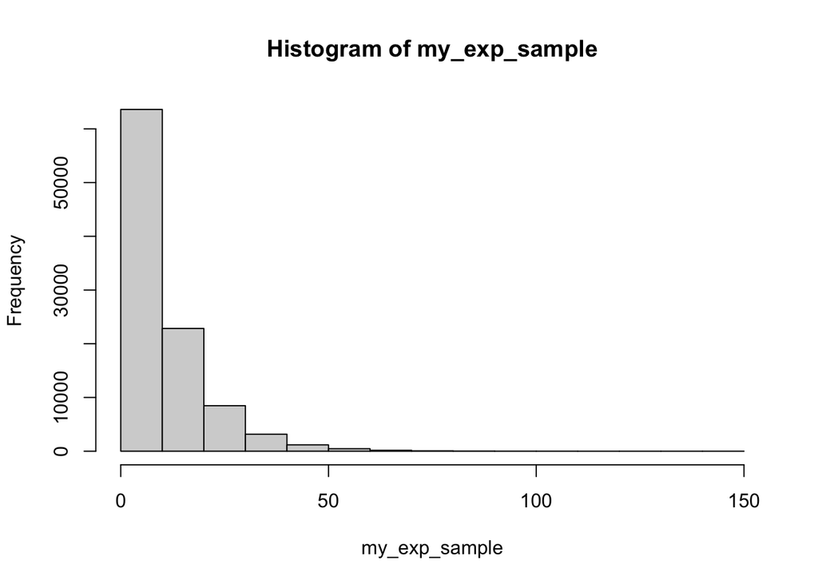

```r
# base R plot for reference
hist(my_exp_sample)
```

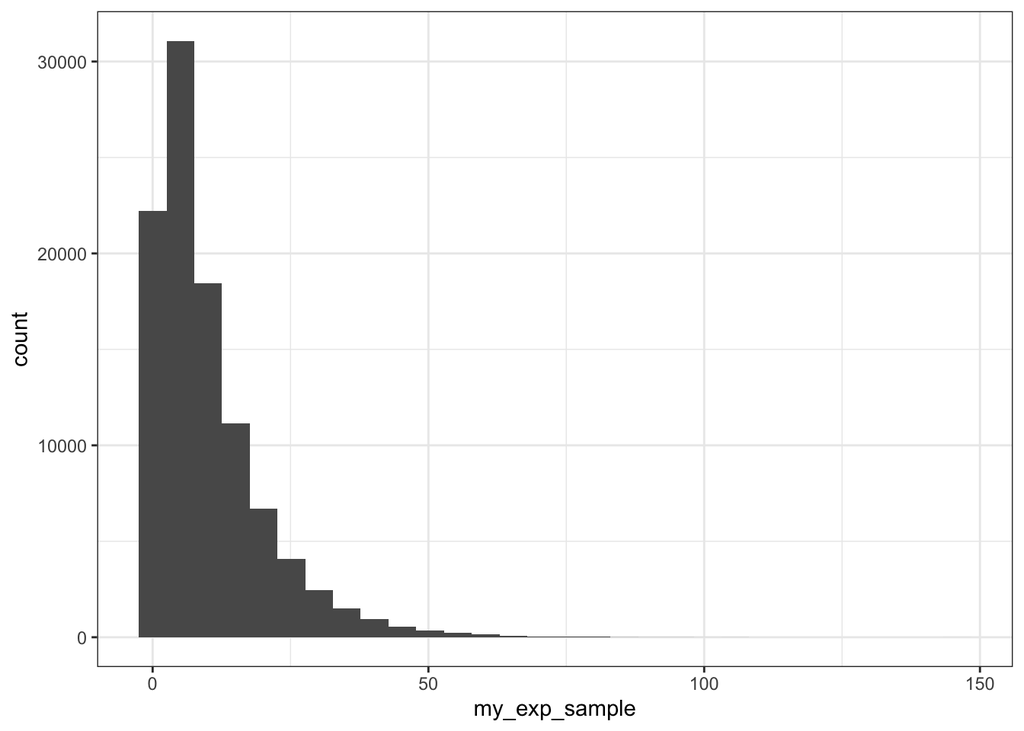

```r
# ggplot
library(tidyverse)
data.frame("my_exp_sample" = my_exp_sample) %>% # Need data frame for ggplot()
  ggplot(aes(x = my_exp_sample)) +
  geom_histogram() +
  theme_bw()# Try changing the number of bins by setting bins = 10
```

**If you have time** : spend a few minutes improving the plot above with recommendations learned last week!

Let’s compare our simulations with simulations produced by the R function `rexp()` (base R function)

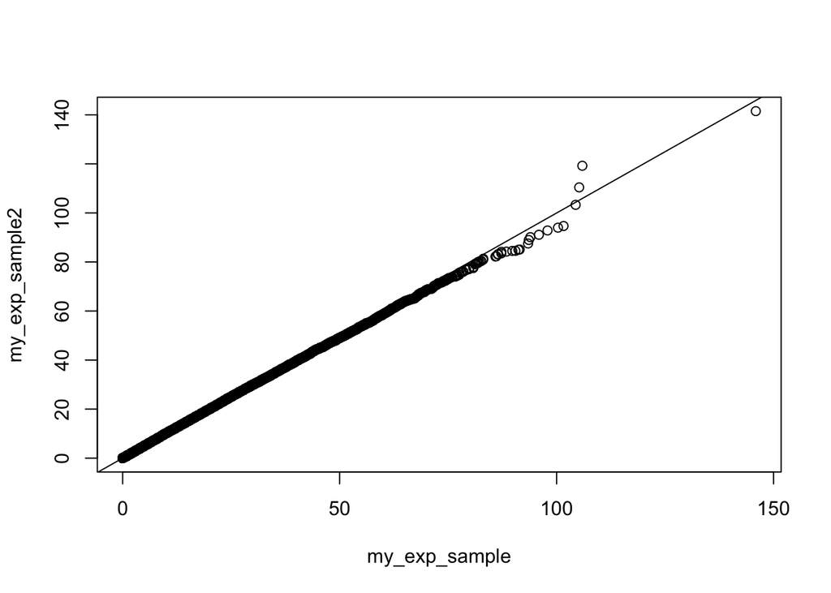

```r
my_exp_sample2 <- rexp(100000, 0.1)

qqplot(my_exp_sample, my_exp_sample2)
abline(0,1)
```

We can also compare empirical and theoretical means and standard deviations

```r
# Parentheses tell R to print the value being stored
(emp_exp_mean <- mean(my_exp_sample))
```

```
[1] 9.99156
```

```r
(theor_exp_mean <- 1/0.1)
```

```
[1] 10
```

```r
(emp_exp_sd <- sd(my_exp_sample))
```

```
[1] 10.07315
```

```r
(theor_exp_sd <- sqrt(1/0.1^2))
```

```
[1] 10
```

After the example, can you better explain why we would want to use the inverse cdf method to generate random samples from an uncommon distribution?

## Exercise 1

Write a function to generate realizations of a normal random variable with a user specified mean and variance. Compare results of your simulations and simulation produced using rnorm().

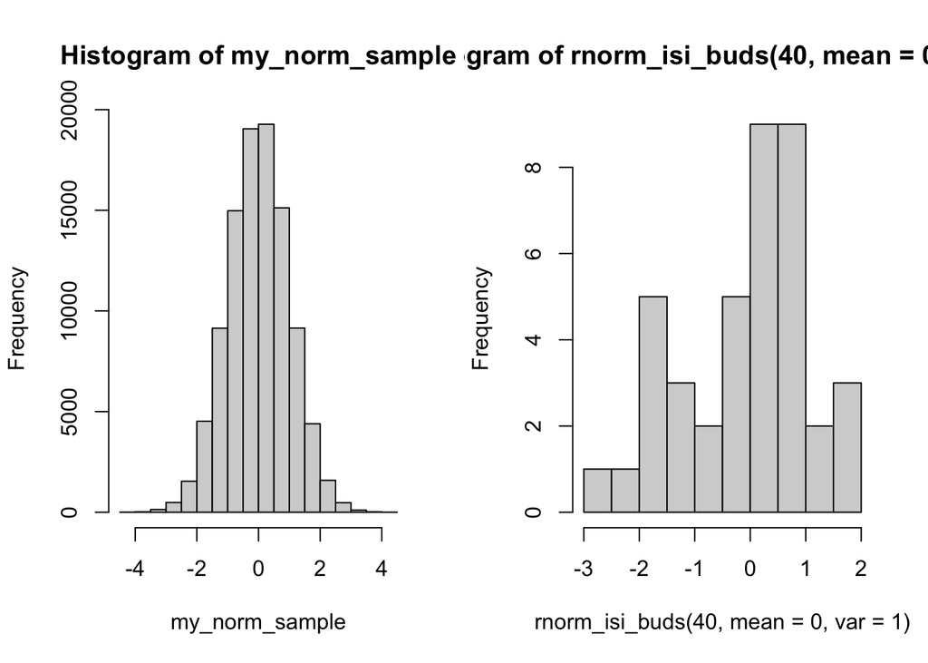

```r
rnorm_isi_buds <- function(num_draws, mean,var){
  runif_draws <- runif(num_draws)
  return(qnorm(runif_draws, mean = mean, sd = sqrt(var)))
}

my_norm_sample <- rnorm_isi_buds(100000, mean = 0, var =1 )

# Looking at different sample sizes
par(mfrow=c(1,2))
hist(my_norm_sample)
hist(rnorm_isi_buds(40, mean=0,var=1))
```

Comparing it to `rnorm` implemented in `base R`:

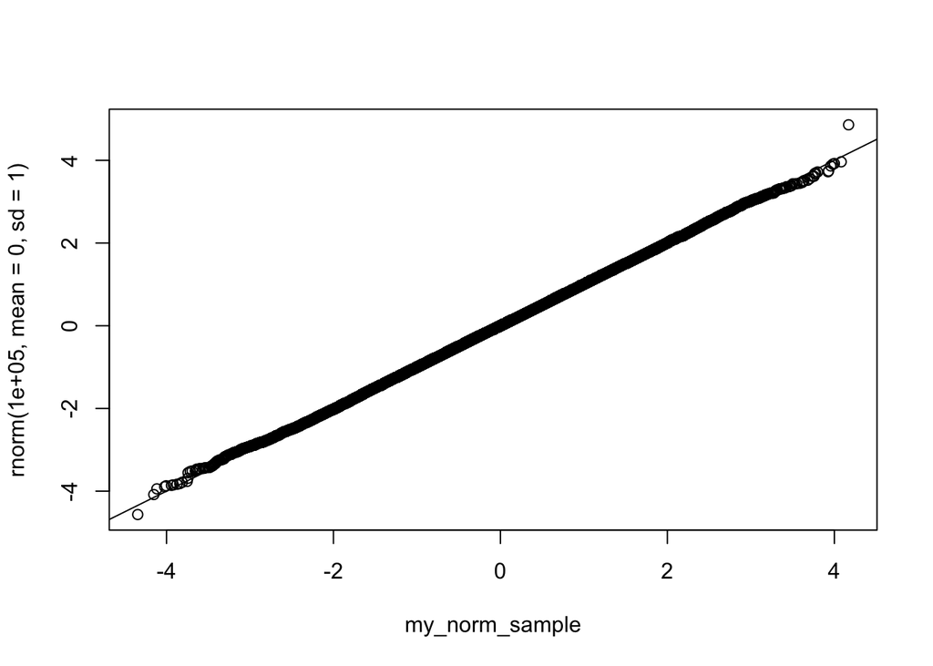

```r
qqplot(my_norm_sample, rnorm(100000,mean = 0,sd = 1))
abline(0,1)
```

(NOTE): the function we implemented takes `variance` as an argument to parametrize the Normal distribution, while `rnorm` takes `sd`. Indeed:

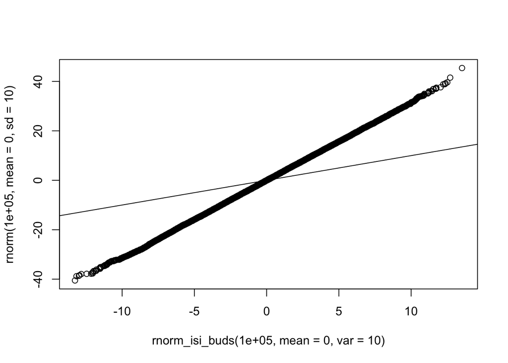

```r
qqplot(

  rnorm_isi_buds(100000, mean = 0, var= 10),
  rnorm(100000, mean = 0, sd= 10 )


)
abline(0,1)
```

# Inverse c.d.f. method for discrete random variables

## Example 2: Bernoulli random variable (aka flip of a biased coin)

```r
rbernoulli <- function(success_prob){
  return_value <- 0

  if (runif(1) < success_prob){
    return_value <- 1 # else statement is not necessary, because we set return_value to 0 from the start
  }

  return(return_value)
}
```

Let’s test our function

```r
num_sim <- 1000
my_coins <- numeric(num_sim)
my_prob <- 0.24

for (i in 1:num_sim){
  my_coins[i] <- rbernoulli(my_prob)
}

mean(my_coins)
```

```
[1] 0.233
```

## Exercise 2

Modify the `rbernoulli()` function so it has 2 arguments: the number of realizations to draw and success probability

Compare the mean number of successes, first from 10 realizations with probability of successs p = 0.2 and 10 realizations with probability of success p = 0.6 ; and then 1000 realizations with each of p=0.2 and p = 0.6. What do you observe?

```r
rbernoulli_draws <- function(num_draws, success_prob){
  bernoulli_sample <- c()
  for(i in 1:num_draws){
    bernoulli_sample[i] <- rbernoulli(success_prob)
  }
  return(bernoulli_sample)
}

sample1_10 <- rbernoulli_draws(10,0.2)
sample2_10 <- rbernoulli_draws(10,0.6)

paste0("Mean for sample size of 10, p = 0.2: ", mean(sample1_10))
```

```
[1] "Mean for sample size of 10, p = 0.2: 0.1"
```

```r
paste0("Mean for sample size of 10, p = 0.6: ", mean(sample2_10))
```

```
[1] "Mean for sample size of 10, p = 0.6: 0.7"
```

```r
sample1_1000 <- rbernoulli_draws(1000,0.2)
sample2_1000 <- rbernoulli_draws(1000,0.6)

paste0("Mean for sample size of 1000, p = 0.2: ", mean(sample1_1000))
```

```
[1] "Mean for sample size of 1000, p = 0.2: 0.187"
```

```r
paste0("Mean for sample size of 1000, p = 0.6: ", mean(sample2_1000))
```

```
[1] "Mean for sample size of 1000, p = 0.6: 0.634"
```

## Exercise 3

Write a function to simulate from a discrete random variable taking values 1, 2, 3 with probabilities p1, p2, p3, supplied by the user of the function. **Note**: you could do it with a `sample()` function, but we don’t want you to use it for this exercise.

```r
rdiscr3 <- function(p1, p2, p3){
  if (abs(1 - p1 - p2 - p3) > 10^-7) { # 10^-7 used to approximate 0
    stop("probabilities must add to 1")
  }

  return_value <- 3

  my_unif <- runif(1)

  if (my_unif < p1) {
    return_value <- 1
  } else if (my_unif < p1 + p2) {
    return_value <- 2
  }

  return(return_value)
}

rdiscr3_ndraws <- function(num_draws, p1, p2, p3){
  random_sample <- c()
  for(i in 1:num_draws){
    random_sample[i] <- rdiscr3(p1,p2,p3)
  }
  return(random_sample)
}
```

The code below should help you test your function. Name your function `rdiscr3`

```r
num_sim <- 10000
test_vector <- rdiscr3_ndraws(num_draws = num_sim, 0.1, 0.2, 0.7)
# Calculate empirical proportions
sum(ifelse(test_vector == 1, yes = 1, no = 0)) / num_sim
```

```
[1] 0.099
```

```r
sum(ifelse(test_vector == 2, yes = 1, no = 0)) / num_sim
```

```
[1] 0.2014
```

```r
sum(ifelse(test_vector == 3, yes = 1, no = 0)) / num_sim
```

```
[1] 0.6996
```

## Exercise 4

- Gamma(3,4) distribution.

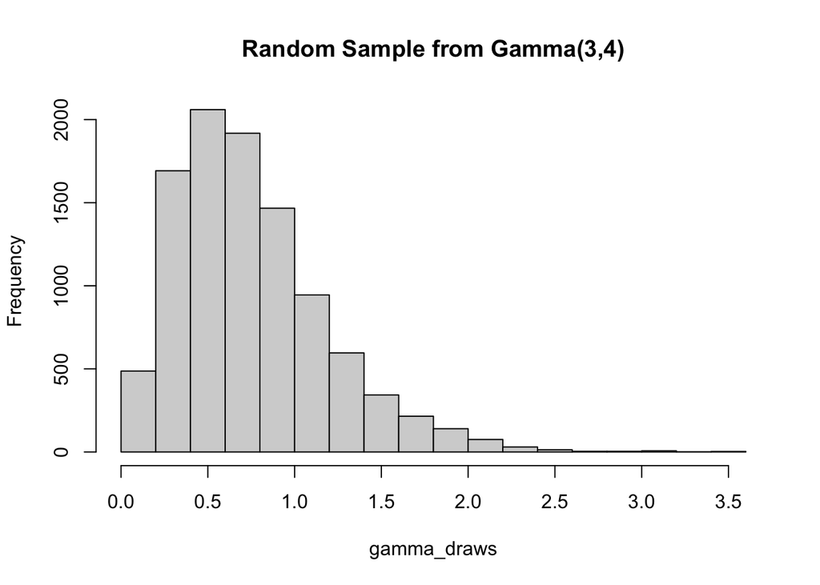

```r
gamma_draws <- rgamma(10000,3,4)
hist(gamma_draws, main = "Random Sample from Gamma(3,4)")
```

- Beta(5,6) distribution.

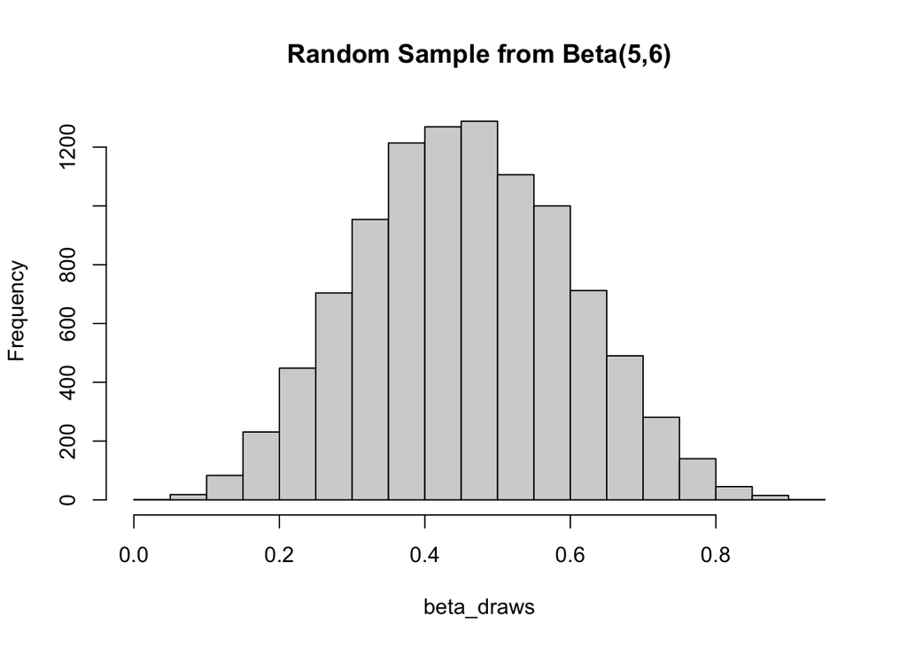

```r
beta_draws <- rbeta(10000, 5,6)
hist(beta_draws, main = "Random Sample from Beta(5,6)")
```

- Poisson(5) distribution.

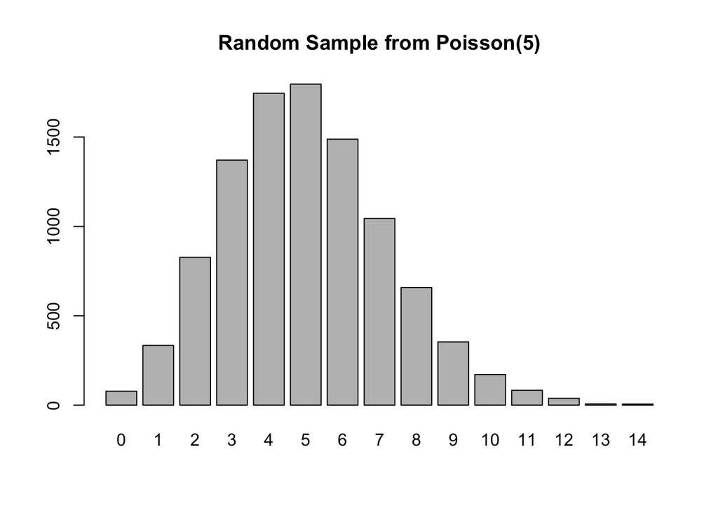

```r
poisson_draws <- rpois(10000,5)
# discrete distribution
barplot(table(poisson_draws), main = "Random Sample from Poisson(5)")
```